# Exercises 1

Danchen Zhao, Shan Qin, Candice Zuo

August 9, 2018

### Part A

Let Right be the event that an user is a right clicker.

Let Random be the event that an user is a random clicker.

Let Yes be the event that the user click “yes”.

Let No be the event that the user click “no”.

Solve for P(Yes|Right)

P(Yes|Random) = 0.5

P(No|Random) = 0.5

P(Random) = 0.3

P(Right) = 1 - P(Random) = 1 - 0.3 = 0.7

P(Yes|Right) = x

P(Yes) = 0.65

P(Yes|Random)P(Random) + P(Yes|Right)P(Right) = 0.65

P(Yes|Right) = 5/7

### Part B

Let Positive be the event that the test result is positive.

Let Negative be the event that the test result is positive.

Let Disease be the event that a person has this disease.

Let Health be the event that a person does not this disease.

Solve for P(Disease|Positive)

P(Positive|Disease) = 0.993

P(Negative|Disease) = 1 - P(Positive|Disease) = 0.007

P(Negative|Health) = 0.9999

P(Positive|Health) = 0.0001

P(Disease) = 0.000025

P(Health) = 0.999975

### Exploratory analysis: green buildings

After analysis, we disagree with the guru. The guru failed to consider the possibility that the positive correlation between green rating and rents are brought by confounding variables but not green rating itself. Analyses are as follow.

First, we cleaned the data to drop the building with less than 10% occupancy.

We believe this can help the analysis because these buildings may not used to rent and their prices may not corresponding to the market price.

We also created a new column “class” that contains all three classes to help the further analysis.

After examine all the correlation plots between variables, we find some of them have relative obvious correlation with rent and green_rating.

We build pairs plots for these variables and check their correlations.

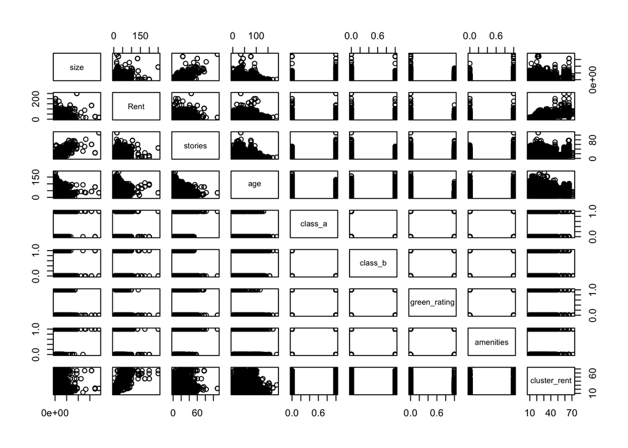

```r
pairs(green_table_clean_leasing_addclass[, c(3,5,7,8,10,11,14,16,23)])
```

```r
cor(green_table_clean_leasing_addclass[, c(3,5,7,8,10,11,14,16,23)])
```

```
##                     size        Rent     stories         age    class_a
## size          1.00000000  0.13325900  0.82575774 -0.20296328  0.4406940
## Rent          0.13325900  1.00000000  0.11109820 -0.10133577  0.2067169
## stories       0.82575774  0.11109820  1.00000000 -0.14528492  0.4492976
## age          -0.20296328 -0.10133577 -0.14528492  1.00000000 -0.5068233
## class_a       0.44069399  0.20671694  0.44929758 -0.50682329  1.0000000
## class_b      -0.27804657 -0.12656366 -0.28828291  0.26963761 -0.7645472
## green_rating  0.09017177  0.02980230  0.03839392 -0.22523781  0.2481154
## amenities     0.38650765  0.05286757  0.37917699 -0.24289767  0.3983044
## cluster_rent -0.02876952  0.75821345 -0.02012161 -0.02923463  0.1063749
##                  class_b green_rating   amenities cluster_rent
## size         -0.27804657   0.09017177  0.38650765  -0.02876952
## Rent         -0.12656366   0.02980230  0.05286757   0.75821345
## stories      -0.28828291   0.03839392  0.37917699  -0.02012161
## age           0.26963761  -0.22523781 -0.24289767  -0.02923463
## class_a      -0.76454715   0.24811536  0.39830438   0.10637487
## class_b       1.00000000  -0.16764157 -0.22734609  -0.07696384
## green_rating -0.16764157   1.00000000  0.11924036  -0.02043843
## amenities    -0.22734609   0.11924036  1.00000000  -0.04885971
## cluster_rent -0.07696384  -0.02043843 -0.04885971   1.00000000
```

From this summary, we could find that buildings with green rating tend to have more amenities, larger size, more class a and smaller age. Meanwhile, rents have positive correlation with size, amenities and class a, and negative correlation with age. It is possible that confounding variables cause the relative higher rent of the buildings with green rating.

We split the data into green building and non-green building.

```r
green_only= subset(green_table_clean_leasing_addclass, green_rating==1)
non_green= subset(green_table_clean_leasing_addclass, green_rating==0)
```

Focus on size, we notice both rent and green building have positive correlation with size, so we divided size into four part to see how rent change in different size range.

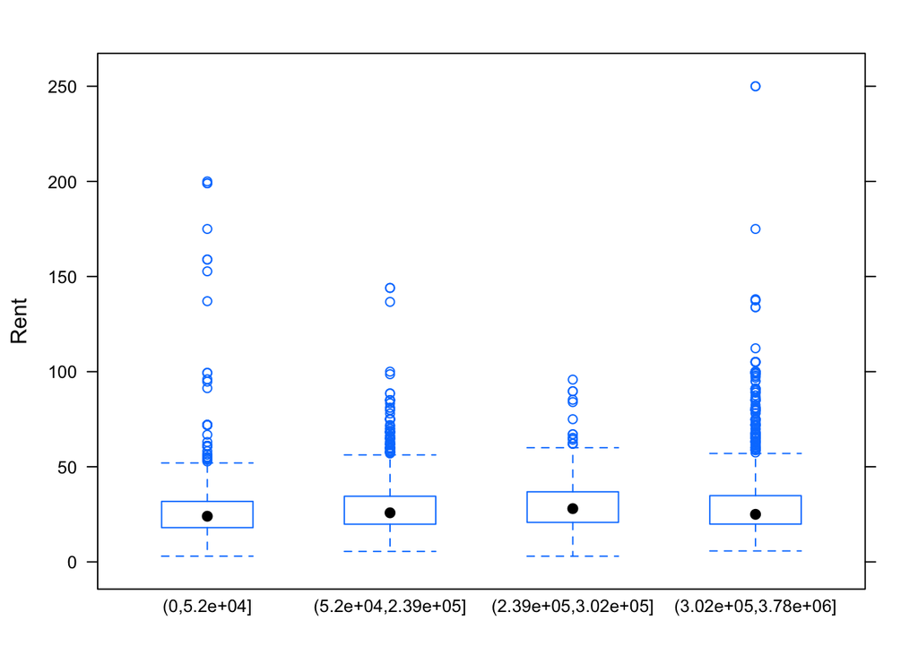

```r
green_table_clean_leasing_addclass$sizecategory = cut(green_table_clean_leasing_addclass$size, breaks=c(0,52000,239465,302375,3781045))
bwplot(Rent ~ sizecategory, data=green_table_clean_leasing_addclass)
```

##### Median rent of green and non-green buildings for each size range.

| size | Green | Non_Green |
| --- | --- | --- |
| 00%-25% | 27.6 | 24 |
| 25%-50% | 28.47 | 25.5 |
| 50%-75% | 30 | 27.95 |
| 75%-100% | 25.97 | 24.91 |

From the data, we find the rent of green building increases relatively bigger when the size is small (<75%).

When the size is large, the increase caused by green building become smaller.

Then we look at class.

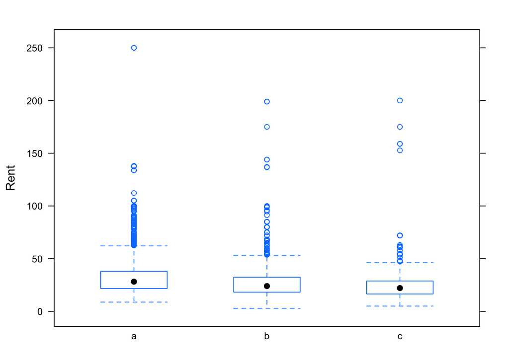

```r
bwplot(Rent ~ class, data=green_table_clean_leasing_addclass)
```

```r
table1=xtabs(~green_rating + class, data=green_table_clean_leasing_addclass)
prop.table(table1, margin=1)
```

```
##             class
## green_rating          a          b          c
##            0 0.37012152 0.48477484 0.14510365
##            1 0.79824561 0.19152047 0.01023392
```

##### Median rent of green and non-green buildings for each class.

| class | Green | Non_Green |
| --- | --- | --- |
| a | 28.44 | 28.2 |
| b | 25.2 | 24 |
| c | 32 | 22.11 |

From the data, we can see green building almost has no rent advantage when the class is a. And from the percentage table, green building has much more class a building comparing to non-green.

There is possibility that the green building has higher median rent because they have more class a building.

To test our theory, we control the variables – age, size, amenities and class, to check the median rent of green and non-green building.

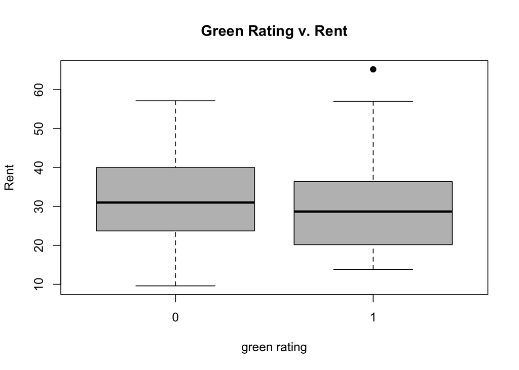

```r
green_table_controlled = subset(green_table_clean_leasing_addclass, age < 10 & size > 52000 & size < 302375 & amenities == 1 & class == 'a')
plot(factor(green_table_controlled$green_rating), green_table_controlled$Rent, pch=19, col='grey', xlab='green rating', ylab='Rent', main='Green Rating v. Rent')
```

As a result, the green building actually has a lower rent range under the control.

Therefore, we can say guru’s statement is wrong. The guru doesn’t consider the effect of other variables on the rent. The higher median rent green building has may be caused by other features shared by most green building.

#### Bootstrapping

```
## [1] "SPY" "TLT" "LQD" "EEM" "VNQ"
```

```
##                ClCl.SPYa    ClCl.TLTa     ClCl.LQDa    ClCl.EEMa
## 2007-01-03            NA           NA            NA           NA
## 2007-01-04  0.0021221123  0.006063328  0.0075152938 -0.013809353
## 2007-01-05 -0.0079763183 -0.004352668 -0.0006526807 -0.029238205
## 2007-01-08  0.0046250821  0.001793566 -0.0002798843  0.007257535
## 2007-01-09 -0.0008498831  0.000000000  0.0001866169 -0.022336235
## 2007-01-10  0.0033315799 -0.004475797 -0.0013063264 -0.002303160
##               ClCl.VNQa
## 2007-01-03           NA
## 2007-01-04  0.001296655
## 2007-01-05 -0.018518518
## 2007-01-08  0.001451392
## 2007-01-09  0.012648208
## 2007-01-10  0.012880523
```

Analyzing the risk/return properties of the five major asset classes:

```
## the expected return for SPY is
```

```
## [1] 100859.9
```

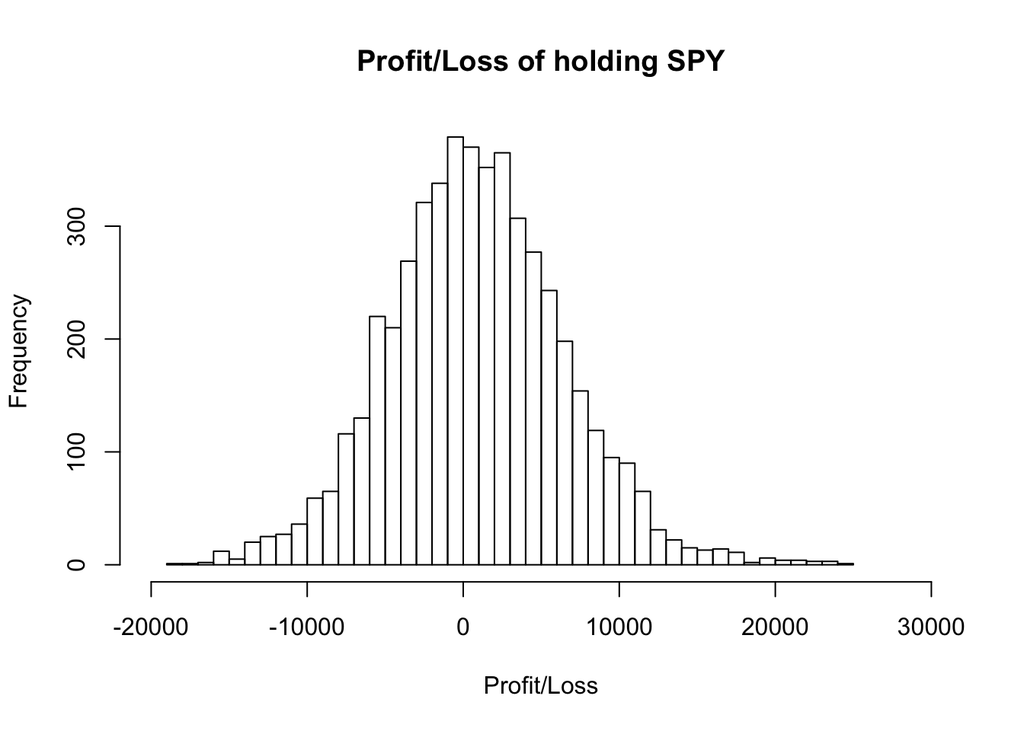

```
## the 5% value at risk for SPY is
```

```
## [1] -8058.488
```

```
## the expected return for TLT is
```

```
## [1] 100501.6
```

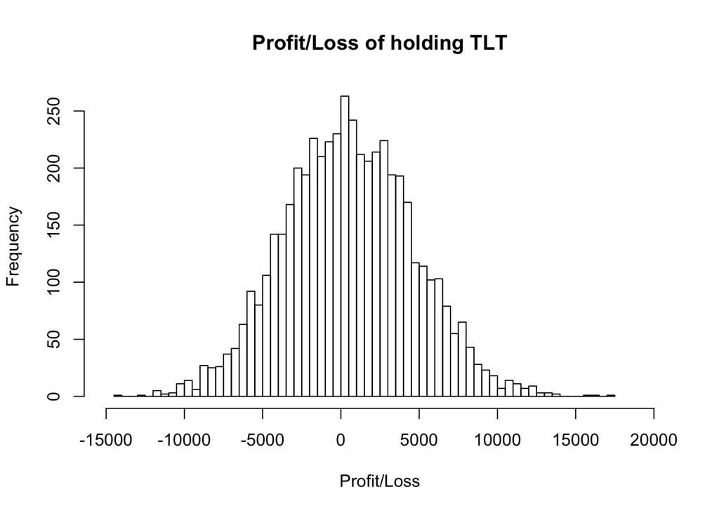

```
## the 5% value at risk for TLT is
```

```
## [1] -6115.421
```

```
## the expected return for LQD is
```

```
## [1] 100382
```

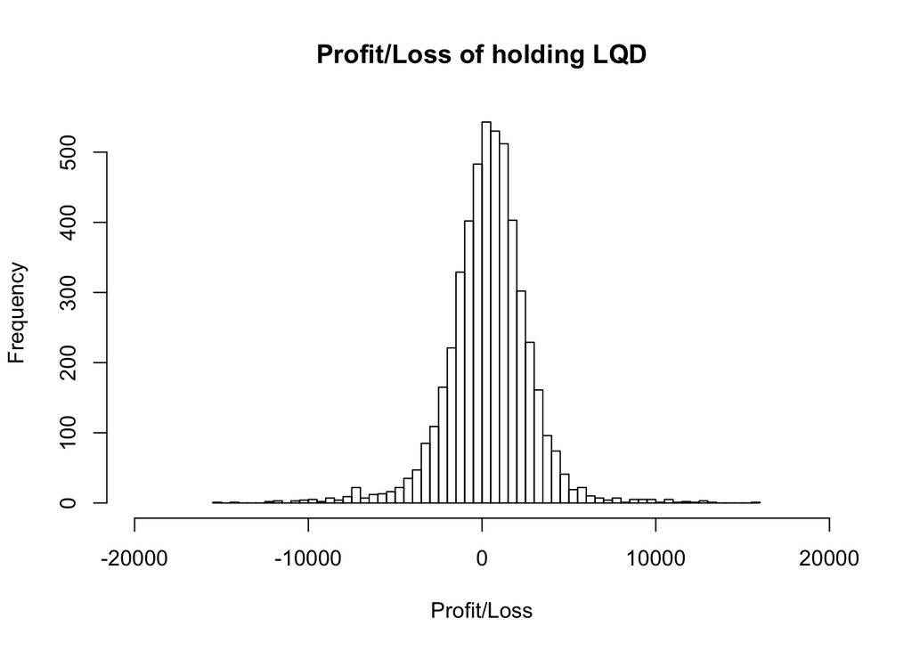

```
## the 5% value at risk for LQD is
```

```
## [1] -3236.454
```

```
## the expected return for EEM is
```

```
## [1] 102110.8
```

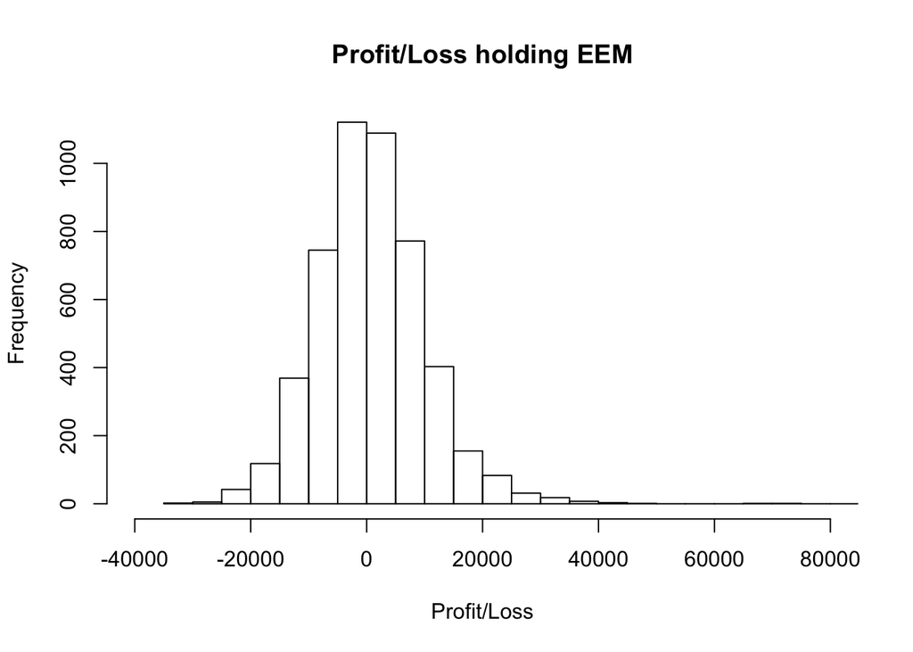

```
## the 5% value at risk for EEM is
```

```
## [1] -13302.82
```

```
## the expected return for VNQ is
```

```
## [1] 100638.2
```

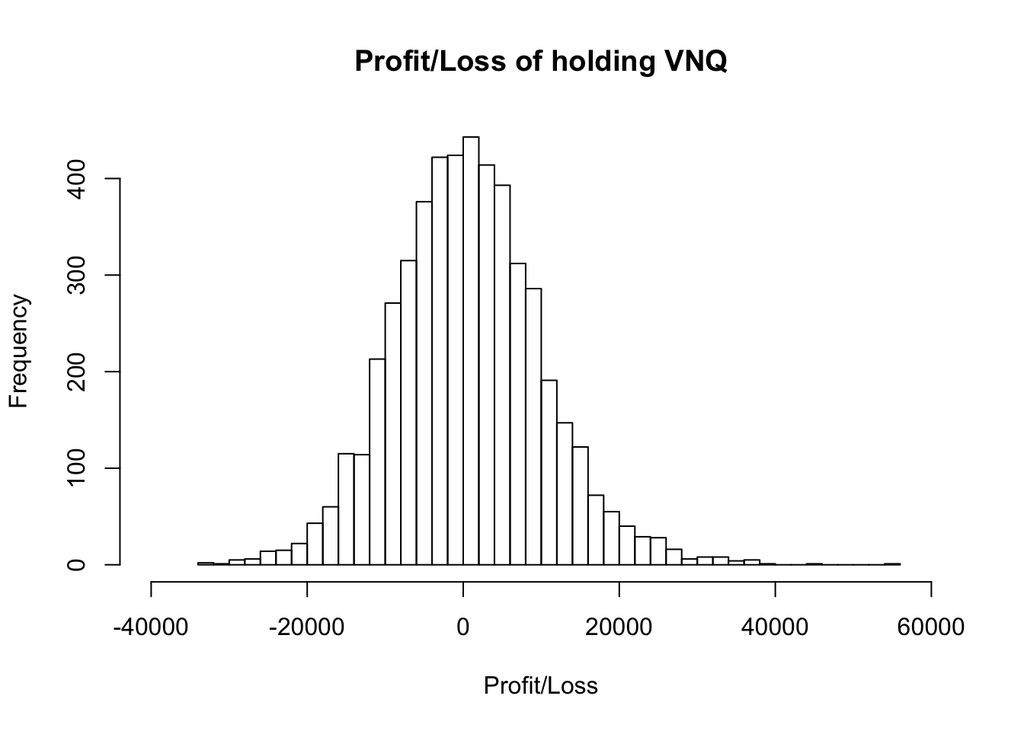

```
## the 5% value at risk for VNQ is
```

```
## [1] -14605.19
```

Suppose we invest $100,000 in each of the five classes and hold those investments for 4 weeks, we can simulate the distributions of profit and loss using bootstrap resampling.

From the simulations, we ranked the assets by return and risks as following (with return raking of 1 being the highest return class and risk ranking of 1 being the lowest risk class):

[output not shown]

```
## the expected return on the even split portfolio is
```

```
## [1] 100878.8
```

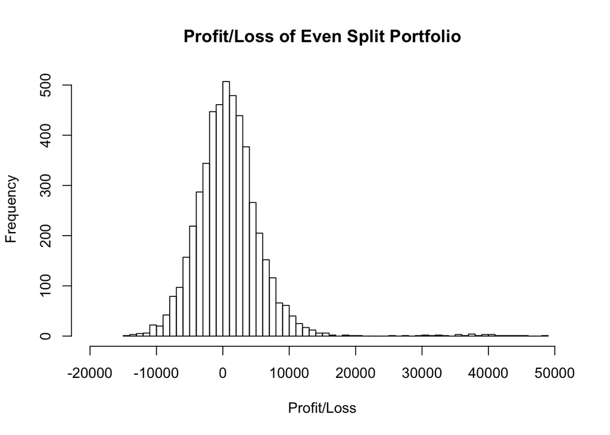

```
## the 5% value at risk for the even split portfolio is
```

```
## [1] -6140.826
```

```r
#Safer Portfolio: we invested 20% of the $100,000 in SPY, 40% in TLT, and 40% in LQD. The top 3 classes that has the lowest risk.
initial_wealth = 100000
set.seed(1)
sim2 = foreach(i=1:5000, .combine='rbind') %do% {
    total_wealth = initial_wealth
    weights = c(0.2, 0.4, 0.4, 0, 0)
    holdings = weights * total_wealth
    n_days = 20
    wealthtracker = rep(0, n_days)
    for(today in 1:n_days) {
        return.today = resample(all_returns, 1, orig.ids=FALSE)
        holdings = holdings + holdings*return.today
        total_wealth = sum(holdings)
        holdings = weights * total_wealth
        wealthtracker[today] = total_wealth
    }
    wealthtracker
}

cat("the expected return on safe portfolio is")
```

```
## the expected return on safe portfolio is
```

```r
# Profit/loss
mean(sim2[,n_days])
```

```
## [1] 100530.7
```

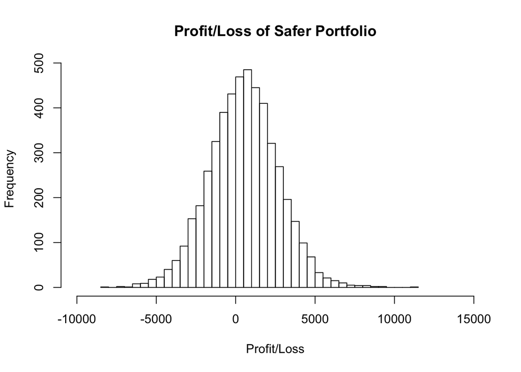

```r
hist(sim2[,n_days]- initial_wealth, breaks=50, xlim = c(-10000, 15000), xlab = 'Profit/Loss', ylab = 'Frequency', main = "Profit/Loss of Safer Portfolio")
```

```r
cat("the 5% value for the safe portfolio is")
```

```
## the 5% value for the safe portfolio is
```

```r
# Calculate 5% value at risk
SAFE_risk = (quantile(sim2[,n_days], 0.05) - initial_wealth)
unname(SAFE_risk)
```

```
## [1] -3011.383
```

```r
#Aggresive Portfolio: we invested 30% of the $100,000 in SPY and 70% in EEM, since they are the top 2 classes with highest return on average.
initial_wealth = 100000
set.seed(1)
sim3 = foreach(i=1:5000, .combine='rbind') %do% {
    total_wealth = initial_wealth
    weights = c(0.3, 0, 0, 0.7, 0)
    holdings = weights * total_wealth
    n_days = 20
    wealthtracker = rep(0, n_days)
    for(today in 1:n_days) {
        return.today = resample(all_returns, 1, orig.ids=FALSE)
        holdings = holdings + holdings*return.today
        total_wealth = sum(holdings)
        holdings = weights * total_wealth
        wealthtracker[today] = total_wealth
    }
    wealthtracker
}

cat("the expected return on the aggressive portfolio is")
```

```
## the expected return on the aggressive portfolio is
```

```r
# Profit/loss
mean(sim3[,n_days])
```

```
## [1] 101555.5
```

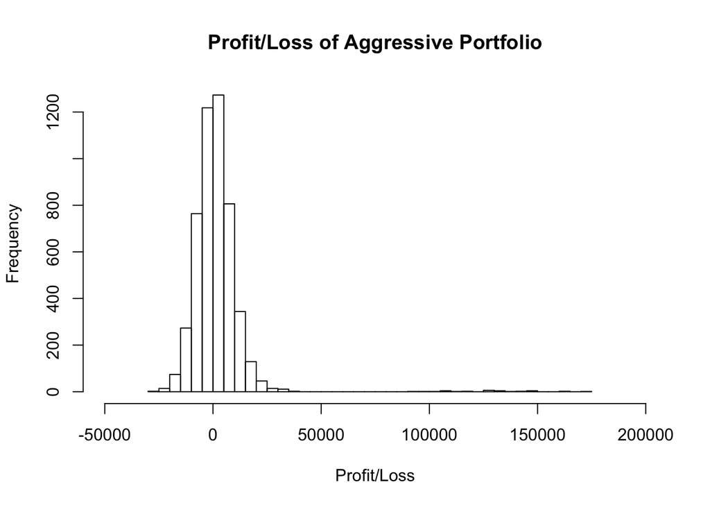

```r
hist(sim3[,n_days]- initial_wealth, breaks=50, xlim = c(-50000,200000),xlab = 'Profit/Loss', ylab = 'Frequency', main = "Profit/Loss of Aggressive Portfolio")
```

```r
cat("the 5% value at risk for the aggressive portfolio is")
```

```
## the 5% value at risk for the aggressive portfolio is
```

```r
# Calculate 5% value at risk
AGG_risk = quantile(sim3[,n_days], 0.05) - initial_wealth
unname(AGG_risk)
```

```
## [1] -11494.4
```

Portfolio Summary:

Even-Split: 20% of $100,000 is invested in each of the five assets

Safer : Invested in the top 3 classes that has the lowest risk (20% in SPY, 40% in TLT, and 40% in LQD)

Aggressive : Invested in the top 2 classes that has the highest return (30% in SPY and 70% in EEM)

Compare the 3 Portfolios:

[output not shown]

The investor can choose among the three options depending on his or her risk tolerance and judgement on the upcoming market. For example, if the investor wants high return, can tolerate high risk, and is confident in the upcoming market, the aggressive portfolio is the best option.

#### Market segmentation

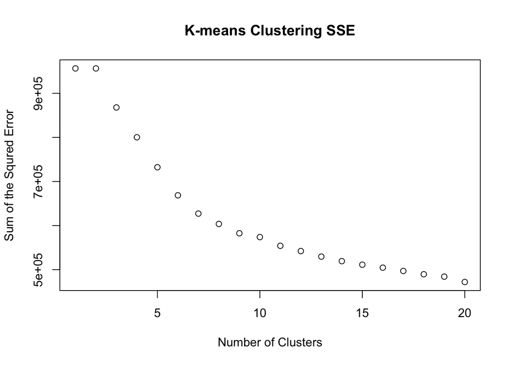

```r
library(LICORS)
consumer_table = read.csv("social_marketing.csv", header = TRUE, sep = ",", row.names = 1)


Z = scale(consumer_table)
betweenss_table = rep(0, 20)
set.seed(1)
for (i in 1:20){
  kmeansPP_consumer = kmeanspp(consumer_table, k=i)
  betweenss_table[i] = kmeansPP_consumer$tot.withinss
}

plot(betweenss_table, xlab='Number of Clusters', ylab='Sum of the Squred Error', main='K-means Clustering SSE')
```

We think keeping “adult”" and “chatter”" category inside the dataset could help us detect protentail spam accounts. Using the elbow method, we determine the optimal cluster number.

We choose 7 according to the plot by the elbow rule.

```r
set.seed(1)
kmeansPP_consumer = kmeanspp(consumer_table, 7, nstart = 10)

print(apply(kmeansPP_consumer$centers,1,function(x) colnames(consumer_table)[order(x, decreasing=TRUE)[1:10]]))
```

```
##       1                  2                3
##  [1,] "sports_fandom"    "politics"       "health_nutrition"
##  [2,] "religion"         "travel"         "personal_fitness"
##  [3,] "food"             "news"           "chatter"
##  [4,] "parenting"        "chatter"        "cooking"
##  [5,] "chatter"          "computers"      "outdoors"
##  [6,] "school"           "photo_sharing"  "photo_sharing"
##  [7,] "family"           "automotive"     "food"
##  [8,] "photo_sharing"    "sports_fandom"  "current_events"
##  [9,] "current_events"   "current_events" "shopping"
## [10,] "health_nutrition" "food"           "politics"
##       4                  5                  6
##  [1,] "chatter"          "chatter"          "cooking"
##  [2,] "photo_sharing"    "photo_sharing"    "photo_sharing"
##  [3,] "current_events"   "shopping"         "fashion"
```

[output cut: 18 more lines]

```r
print(kmeansPP_consumer$size)
```

```
## [1]  607  557  933 3686 1209  493  397
```

[output not shown]

The fifth cluster tends to be college students who love internet and social medias.

```r
consumer_scaled <- scale(consumer_table, center=TRUE, scale=TRUE)

consumer_distance_matrix = dist(consumer_scaled, method='euclidean')
hier_consumer = hclust(consumer_distance_matrix, method='average')


H_cluster = cutree(hier_consumer, k = 7)
summary(factor(H_cluster))
```

```
##    1    2    3    4    5    6    7
## 7864   10    2    2    1    2    1
```

The hierarchical clustering give us a strange result. It seems like most of clusters are composed of outliers.

```r
consumer2_scaled <- scale(consumer_table[which(H_cluster == 1),], center=TRUE, scale=TRUE)

consumer2_distance_matrix = dist(consumer2_scaled, method='euclidean')
hier2_consumer = hclust(consumer2_distance_matrix, method='average')


H_cluster2 = cutree(hier2_consumer, k = 7)
summary(factor(H_cluster2))
```

```
##    1    2    3    4    5    6    7
## 7796   47    2   11    5    2    1
```

Another hierarchical cluster within cluster 1 does not solve this problem.

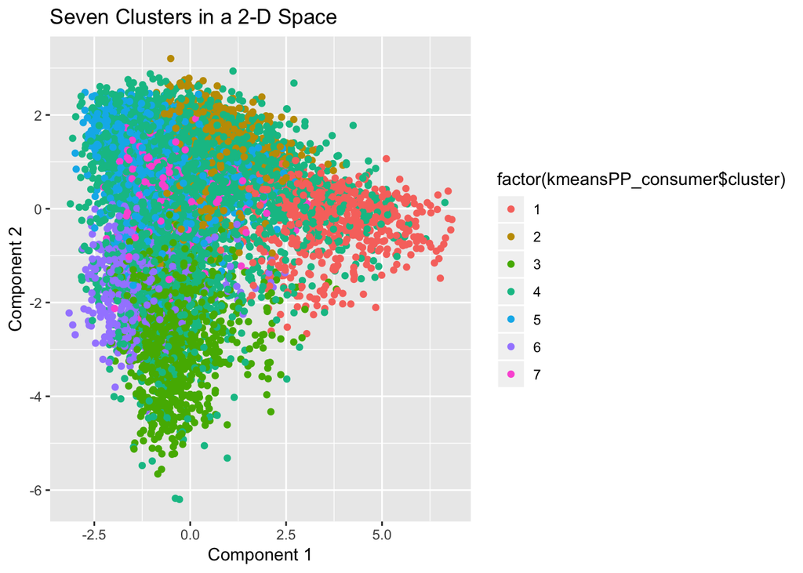

[output not shown]

```r
Z = consumer_table/rowSums(consumer_table)
set.seed(1)
pc2 = prcomp(Z, scale=TRUE, rank=2)
loadings = pc2$rotation
scores = pc2$x

qplot(scores[,1], scores[,2], color=factor(kmeansPP_consumer$cluster), xlab='Component 1', ylab='Component 2', main = 'Seven Clusters in a 2-D Space')
```

The first cluster tends to be religious, who love sports, and who are parents and community-minded.

The second cluster values intellectual enjoyments.

The third cluster cares about both the world and themselves.

The fourth cluster loves social activities.

The seventh cluster loves automotive and arts.

From k-means and PCA, we found some common groups: people with liberal thoughts(enjoy intelligent activities and care about health), people who care about personal images, and traditional family people who pay attention to cars, parenting and schools, people value fitness, and people who like indoor activities. There is an interesting findings: photo-sharing is common among different clusters. We think it is because the whole data set is gained from the social media, where people like to share photos.